# Harmonization of a test dataset using ComBat parameters estimated from a training dataset

Jean-Philippe Fortin

fortin946@gmail.com

2020-07-16

# 1 Intro

Vignette describing a function in development, `neuroCombatFromTraining`. The function applies ComBat scanner correction factors estimated from a training dataset to a test dataset. Scanners/sites of the test dataset must be included in the training dataset.

# 2 Example dataset

We use the example dataset stored in the `neuroCombat` package: 10 scans from 2 scanners, with 200 imaging features. Scans come from either a normal or disease brain.

```r
library(neuroCombat)
data  <- combatExampleData
batch <- combatExampleBatch
pheno <- combatExamplePheno
mod   <- model.matrix(~pheno)
batch
```

```
##  [1] "Scanner1" "Scanner1" "Scanner1" "Scanner1" "Scanner1" "Scanner2"
##  [7] "Scanner2" "Scanner2" "Scanner2" "Scanner2"
```

```r
pheno
```

```
##  [1] "Normal"  "Disease" "Normal"  "Disease" "Normal"  "Disease" "Normal"
##  [8] "Disease" "Normal"  "Disease"
```

```r
head(data)
```

```
##             Scan_1     Scan_2   Scan_3      Scan_4    Scan_5   Scan_6    Scan_7
## Feature_1 3.018746  1.2155138 2.920543 -0.90197026 0.8749314 9.075021 14.242014
## Feature_2 2.815747  0.3308765 4.181752 -0.05474996 3.5211787 7.929139  8.127343
## Feature_3 1.628669  1.3902751 5.186144 -1.35675471 2.9535771 7.860847 12.091550
## Feature_4 2.400832  0.8720470 3.406175  0.31723058 1.8505283 8.749058 12.491624
## Feature_5 3.294545 -1.0808170 2.261641  1.39571912 3.6293383 7.165525 12.192988
## Feature_6 3.389794  0.4958216 1.043513 -1.21122382 2.2735285 7.932516 11.254680
##              Scan_8   Scan_9  Scan_10
## Feature_1  7.915276 14.43978 7.428021
## Feature_2  7.177166 12.65664 8.036537
## Feature_3 10.062406 10.74085 8.713484
## Feature_4  9.807647 13.28089 8.471584
## Feature_5  7.145679 13.05886 8.399076
## Feature_6  4.385352 12.67439 6.912409
```

# 3 Testing if the code works as intended

Training: full dataset (10 scans) Test: subset of the full dataset (4 scans, 2 from each scanner)

```r
indices.training <- c(1:10)
indices.test     <- c(1,2,6,7)
data.training    <- data[, indices.training]
data.test        <- data[, indices.test]
batch.training   <- batch[indices.training]
batch.test       <- batch[indices.test]
```

## 3.1 Scenario 1: no covariates adjustment in training dataset and no covariates adjustment in test dataset

We estimate scanner effects using the full dataset as training dataset, and apply the scanner correction on the test dataset. We don’t apply any covariates adjustment. Since the test dataset is part of the training dataset, we should obtain identical harmonized data.

```r
data.training.harmonized <- neuroCombat(data.training, batch=batch.training)
```

```
## [neuroCombat] Performing ComBat with empirical Bayes
## [combat] Found 2 batches
## [combat] Adjusting for  0  covariate(s) or covariate level(s)
## [neuroCombat] Standardizing Data across features
## [neuroCombat] Fitting L/S model and finding priors
## [neuroCombat] Finding parametric adjustments
## [neuroCombat] Adjusting the Data
```

```r
data.test.harmonized <- neuroCombatFromTraining(data.test, batch=batch.test, estimates=data.training.harmonized$estimates)
```

```
## [neuroCombatFromTraining] In development ...
```

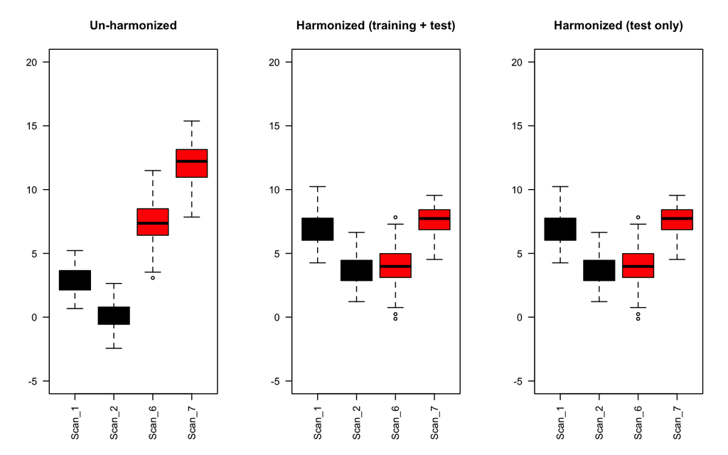

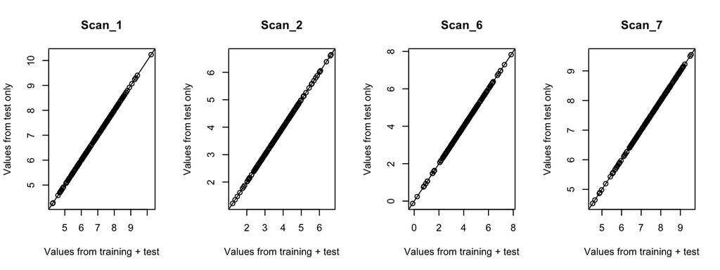

Alright, it seems to be working as intended.

## 3.2 Scenario 2: covariates adjustment in training dataset, but no covariates adjustment in test dataset

In this scenario, since no covariates are provided in the test dataset, we expect the harmonized data from the training and test datasets to differ. This happens because the internal data standardization prior to scanner correction in the ComBat algorithm takes into account covariates.

To standardize the test dataset, we use an average of the standardization factors from the training dataset.

```r
data.training.harmonized <- neuroCombat(data.training, batch=batch.training, mod=mod)
```

```
## [neuroCombat] Performing ComBat with empirical Bayes
## [combat] Found 2 batches
## [combat] Adjusting for  1  covariate(s) or covariate level(s)
## [neuroCombat] Standardizing Data across features
## [neuroCombat] Fitting L/S model and finding priors
## [neuroCombat] Finding parametric adjustments
## [neuroCombat] Adjusting the Data
```

```r
data.test.harmonized <- neuroCombatFromTraining(data.test, batch=batch.test, estimates=data.training.harmonized$estimates)
```

```
## [neuroCombatFromTraining] In development ...
## [neuroCombatFromTraining] Using mean imputation to account for previous covariates adjustment in training dataset
```

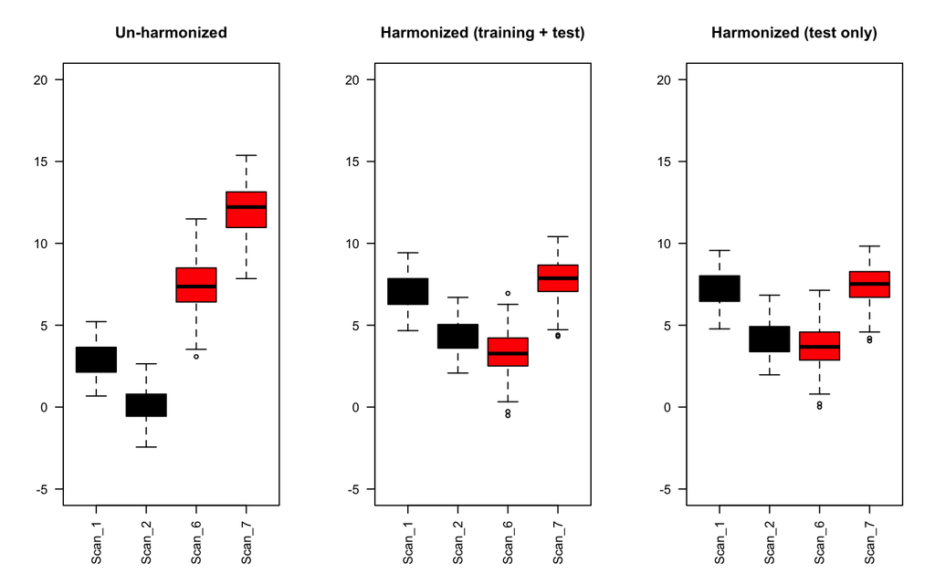

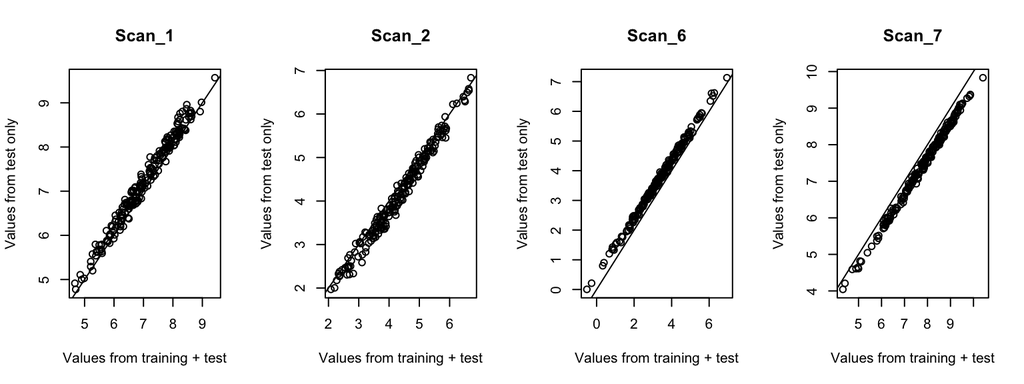

As expected, there are subtle differences between the training and test datasets, but overall the scanner correction appears to be successful.

## 3.3 Scenario 3: covariates adjustment in training dataset, and covariates adjustment in test dataset

Not supported yet.

# 4 References